# Project Datamining - team 4

Team 4 Healthcare case study

5/16/2021

## Member

- Đào Văn Thắng 18133050
- Đặng Ngọc Sơn 18133046
- Hà Hải Long 17110326
- Trần Minh Tú Trung 18133060

## Dataset

In this dataset there are total of 600 observations and 10 variables.9 variables are numeric and 1 variable is categorical.

| Variables | Meaning |
| --- | --- |
| Thickness_of_Clump | Độ dày của khối |
| Cell_Size_Uniformity | Sự đồng nhất về kích thước ô tế bào |
| Cell_Shape_Uniformity | Tính đồng nhất của hình dạng tế bào |
| Single_Epithelial_Cell_Size | Kích thước tế bào biểu mô đơn |
| Bare_Nuclei | Hạt nhân trần |
| Bland_Chromatin | Chất nhiễm sắc nhạt |
| Normal_Nucleoli | Nucleoli bình thường |
| Mitoses | khả năng nguyên phân nhân đôi tế bào |
| Outcome | Bệnh nhân có bị ung thư hay không |

Kết quả (`Outcome`) là biến đích trong dữ liệu, trong đó Có biểu thị sự hiện diện của ung thư ác tính và Không biểu thị là không có ung thư ác tính.

Giá trị đầu vào(`input`): “Thickness_of_Clump”, “Cell_Size_Uniformity”, “Cell_Shape_Uniformity”, “Marginal_Adhesion”, “Single_Epithelial_Cell_Size”, “Bare_Nuclei”, “Bland_Chromatin”, “Normal_Nucleoli”, “Mitoses”.

Giá trị cần dự đoán (`Output`): “Outcome”.

Phương pháp đánh giá: Sai số ngoài túi (OOB) hoặc tỷ lệ phân loại sai.

Độ đo: confusion matrix.

Nhóm sử dụng thuật toán RandomForest , Descision Tree, knn, Navie bayes.

```r
data1 <- read.csv ("Chapter_05_synthetic_cancer_data.csv",header=TRUE,sep=",")
# remove Sample_No from data 1
data1 <- data1[,-1]
```

```r
# display top 6 rows of dataset to see how data look like

head (data1)
```

```
##   Thickness_of_Clump Cell_Size_Uniformity Cell_Shape_Uniformity
## 1                  6                    2                     2
## 2                  6                    6                     5
## 3                  3                    2                     3
## 4                  7                    9                     9
## 5                  6                    3                     1
## 6                  8                   10                    10
##   Marginal_Adhesion Single_Epithelial_Cell_Size Bare_Nuclei Bland_Chromatin
## 1                 2                           2           2               5
## 2                 6                           7          10               5
## 3                 1                           2           2               4
## 4                 2                           4           4               4
## 5                 4                           3           3               4
## 6                 9                           7          10               9
##   Normal_Nucleoli Mitoses Outcome
## 1               1       1      No
## 2               2       2      No
## 3               2       2      No
## 4               7       2      No
## 5               3       1      No
## 6               9       2     Yes
```

```r
# display bottom 6 rows

tail(data1)
```

```
##     Thickness_of_Clump Cell_Size_Uniformity Cell_Shape_Uniformity
## 595                  4                    8                     7
## 596                  7                    3                     1
## 597                  6                    2                     4
## 598                  6                    1                     3
## 599                  5                    3                     2
## 600                  6                    4                     5
##     Marginal_Adhesion Single_Epithelial_Cell_Size Bare_Nuclei Bland_Chromatin
## 595                 3                           5          10               9
## 596                 1                           4           3               4
## 597                 1                           2           1               4
## 598                 1                           2           1               4
## 599                 3                           2           1               2
## 600                 2                           1           3               1
##     Normal_Nucleoli Mitoses Outcome
## 595               1       2     Yes
## 596               1       2      No
## 597               1       2      No
## 598               1       2      No
## 599               3       2      No
## 600               2       1      No
```

```r
# describe the structure of data

str(data1)
```

```
## 'data.frame':    600 obs. of  10 variables:
##  $ Thickness_of_Clump         : int  6 6 3 7 6 8 3 4 4 6 ...
##  $ Cell_Size_Uniformity       : int  2 6 2 9 3 10 2 3 2 2 ...
##  $ Cell_Shape_Uniformity      : int  2 5 3 9 1 10 1 2 1 3 ...
##  $ Marginal_Adhesion          : int  2 6 1 2 4 9 1 2 2 1 ...
##  $ Single_Epithelial_Cell_Size: int  2 7 2 4 3 7 3 2 3 4 ...
##  $ Bare_Nuclei                : int  2 10 2 4 3 10 10 1 3 1 ...
##  $ Bland_Chromatin            : int  5 5 4 4 4 9 5 3 1 2 ...
##  $ Normal_Nucleoli            : int  1 2 2 7 3 9 2 2 3 2 ...
##  $ Mitoses                    : int  1 2 2 2 1 2 1 2 5 1 ...
##  $ Outcome                    : chr  "No" "No" "No" "No" ...
```

```r
#display the column name of the data

names(data1)
```

```
##  [1] "Thickness_of_Clump"          "Cell_Size_Uniformity"
##  [3] "Cell_Shape_Uniformity"       "Marginal_Adhesion"
##  [5] "Single_Epithelial_Cell_Size" "Bare_Nuclei"
##  [7] "Bland_Chromatin"             "Normal_Nucleoli"
##  [9] "Mitoses"                     "Outcome"
```

```r
# display the datatype

class(data1)
```

```
## [1] "data.frame"
```

```r
# Check the missing values present in the data

#is.na(data2)


#to check the percentage of benign and malignant breast cancer in the data

table(data1$Outcome)/nrow(data1)
```

```
##
##        No       Yes
## 0.6333333 0.3666667
```

# Tren thuat toan Random Forest

```r
#install.packages("randomForest")
#install.packages("glm")
library(randomForest)
library(pROC)
#Building Random Forests model on full data
data1$Outcome = factor(data1$Outcome)
rf_model <- randomForest(Outcome ~ ., data=data1, ntree=1500,mtry=3,importance=TRUE)

rf_model
```

```
##
## Call:
##  randomForest(formula = Outcome ~ ., data = data1, ntree = 1500,      mtry = 3, importance = TRUE)
##                Type of random forest: classification
##                      Number of trees: 1500
## No. of variables tried at each split: 3
##
##         OOB estimate of  error rate: 3.5%
## Confusion matrix:
##      No Yes class.error
## No  366  14  0.03684211
## Yes   7 213  0.03181818
```

```r
library(class)
library(caTools)
library(caret)
library(gmodels)
#Set seed in order to reproduce the sample

set.seed(2)

#splitting data set into training and testing dataset in 70:30


sample <- sample.split(data1$Outcome,SplitRatio=0.70)

#No of observations in train dataset

train_data <- subset(data1,sample==TRUE)

# No of observations  in test dataset

test_data <- subset(data1,sample==FALSE)
```

cach tim mtry

```r
trControl <- trainControl(method = "cv",
    number = 5,
    search = "grid")


set.seed(1234)
tuneGrid <- expand.grid(.mtry = c(1: 10))
rf_mtry <- train(Outcome~.,
    data = train_data,
    method = "rf",
    metric = "Accuracy",
    tuneGrid = tuneGrid,
    trControl = trControl,
    importance = TRUE,
    nodesize = 14,
    ntree = 1500)
print(rf_mtry)
```

```
## Random Forest
##
## 420 samples
##   9 predictor
##   2 classes: 'No', 'Yes'
##
## No pre-processing
## Resampling: Cross-Validated (5 fold)
## Summary of sample sizes: 336, 336, 335, 337, 336
## Resampling results across tuning parameters:
##
##   mtry  Accuracy   Kappa
##    1    0.9642830  0.9236888
##    2    0.9642550  0.9233843
##    3    0.9571682  0.9087553
##    4    0.9571962  0.9091872
##    5    0.9571962  0.9091872
##    6    0.9548152  0.9042446
##    7    0.9548152  0.9042446
##    8    0.9548152  0.9042446
##    9    0.9548152  0.9042446
##   10    0.9524343  0.8990980
##
## Accuracy was used to select the optimal model using the largest value.
## The final value used for the model was mtry = 1.
```

```r
best_mtry <- rf_mtry$bestTune$mtry
best_mtry
```

```
## [1] 1
```

```r
# tim maxnode
store_maxnode <- list()
tuneGrid <- expand.grid(.mtry = best_mtry)
for (maxnodes in c(20: 30)) {
    set.seed(1234)
    rf_maxnode <- train(Outcome~.,
        data = train_data,
        method = "rf",
        metric = "Accuracy",
        tuneGrid = tuneGrid,
        trControl = trControl,
        importance = TRUE,
        nodesize = 14,
        maxnodes = maxnodes,
        ntree = 300)
    current_iteration <- toString(maxnodes)
    store_maxnode[[current_iteration]] <- rf_maxnode
}
results_mtry <- resamples(store_maxnode)
summary(results_mtry)
```

```
##
## Call:
## summary.resamples(object = results_mtry)
##
## Models: 20, 21, 22, 23, 24, 25, 26, 27, 28, 29, 30
## Number of resamples: 5
##
## Accuracy
##         Min.  1st Qu.    Median      Mean   3rd Qu.      Max. NA's
## 20 0.9518072 0.952381 0.9642857 0.9642550 0.9647059 0.9880952    0
## 21 0.9518072 0.952381 0.9529412 0.9619021 0.9642857 0.9880952    0
## 22 0.9518072 0.952381 0.9529412 0.9619021 0.9642857 0.9880952    0
## 23 0.9518072 0.952381 0.9529412 0.9619021 0.9642857 0.9880952    0
## 24 0.9518072 0.952381 0.9529412 0.9619021 0.9642857 0.9880952    0
## 25 0.9518072 0.952381 0.9529412 0.9619021 0.9642857 0.9880952    0
## 26 0.9518072 0.952381 0.9529412 0.9619021 0.9642857 0.9880952    0
## 27 0.9518072 0.952381 0.9529412 0.9619021 0.9642857 0.9880952    0
## 28 0.9518072 0.952381 0.9529412 0.9619021 0.9642857 0.9880952    0
## 29 0.9518072 0.952381 0.9529412 0.9619021 0.9642857 0.9880952    0
## 30 0.9518072 0.952381 0.9529412 0.9619021 0.9642857 0.9880952    0
##
## Kappa
##         Min.  1st Qu.    Median      Mean   3rd Qu.     Max. NA's
## 20 0.8970862 0.897748 0.9227941 0.9235217 0.9253731 0.974607    0
## 21 0.8970862 0.897748 0.9011628 0.9186796 0.9227941 0.974607    0
## 22 0.8970862 0.897748 0.9011628 0.9186796 0.9227941 0.974607    0
## 23 0.8970862 0.897748 0.9011628 0.9186796 0.9227941 0.974607    0
## 24 0.8970862 0.897748 0.9011628 0.9186796 0.9227941 0.974607    0
## 25 0.8970862 0.897748 0.9011628 0.9186796 0.9227941 0.974607    0
## 26 0.8970862 0.897748 0.9011628 0.9186796 0.9227941 0.974607    0
## 27 0.8970862 0.897748 0.9011628 0.9186796 0.9227941 0.974607    0
## 28 0.8970862 0.897748 0.9011628 0.9186796 0.9227941 0.974607    0
## 29 0.8970862 0.897748 0.9011628 0.9186796 0.9227941 0.974607    0
## 30 0.8970862 0.897748 0.9011628 0.9186796 0.9227941 0.974607    0
```

tìm ntree

```r
store_maxtrees <- list()
for (ntree in c(250, 300, 350, 400, 450, 500, 550, 800, 1000, 1500, 2000)) {
    set.seed(5678)
    rf_maxtrees <- train(Outcome~.,
        data = train_data,
        method = "rf",
        metric = "Accuracy",
        tuneGrid = tuneGrid,
        trControl = trControl,
        importance = TRUE,
        nodesize = 14,
        maxnodes = 15,
        ntree = ntree)
    key <- toString(ntree)
    store_maxtrees[[key]] <- rf_maxtrees
}
results_tree <- resamples(store_maxtrees)
summary(results_tree)
```

```
##
## Call:
## summary.resamples(object = results_tree)
##
## Models: 250, 300, 350, 400, 450, 500, 550, 800, 1000, 1500, 2000
## Number of resamples: 5
##
## Accuracy
##           Min.   1st Qu.    Median      Mean   3rd Qu.      Max. NA's
## 250  0.9518072 0.9642857 0.9642857 0.9666079 0.9761905 0.9764706    0
## 300  0.9518072 0.9642857 0.9642857 0.9642550 0.9647059 0.9761905    0
## 350  0.9518072 0.9642857 0.9642857 0.9642550 0.9647059 0.9761905    0
## 400  0.9397590 0.9642857 0.9642857 0.9618454 0.9647059 0.9761905    0
## 450  0.9397590 0.9642857 0.9642857 0.9618454 0.9647059 0.9761905    0
## 500  0.9518072 0.9642857 0.9642857 0.9642550 0.9647059 0.9761905    0
## 550  0.9518072 0.9642857 0.9642857 0.9642550 0.9647059 0.9761905    0
## 800  0.9518072 0.9642857 0.9642857 0.9642550 0.9647059 0.9761905    0
## 1000 0.9518072 0.9642857 0.9642857 0.9642550 0.9647059 0.9761905    0
## 1500 0.9397590 0.9642857 0.9642857 0.9618454 0.9647059 0.9761905    0
## 2000 0.9397590 0.9642857 0.9642857 0.9618454 0.9647059 0.9761905    0
##
## Kappa
##           Min.   1st Qu.   Median      Mean   3rd Qu.      Max. NA's
## 250  0.8955975 0.9238210 0.924821 0.9286025 0.9492234 0.9495495    0
## 300  0.8955975 0.9233083 0.923821 0.9234195 0.9248210 0.9495495    0
## 350  0.8955975 0.9233083 0.923821 0.9234195 0.9248210 0.9495495    0
## 400  0.8685461 0.9233083 0.923821 0.9180092 0.9248210 0.9495495    0
## 450  0.8685461 0.9233083 0.923821 0.9180092 0.9248210 0.9495495    0
## 500  0.8955975 0.9233083 0.923821 0.9234195 0.9248210 0.9495495    0
## 550  0.8955975 0.9233083 0.923821 0.9234195 0.9248210 0.9495495    0
## 800  0.8955975 0.9233083 0.923821 0.9234195 0.9248210 0.9495495    0
## 1000 0.8955975 0.9233083 0.923821 0.9234195 0.9248210 0.9495495    0
## 1500 0.8704340 0.9233083 0.923821 0.9183868 0.9248210 0.9495495    0
## 2000 0.8704340 0.9233083 0.923821 0.9183868 0.9248210 0.9495495    0
```

```r
library(randomForest)
fit_rf <- train(Outcome~.,
    train_data,
    method = "rf",
    metric = "Accuracy",
    tuneGrid = tuneGrid,
    trControl = trControl,
    importance = TRUE,
    nodesize = 14,
    ntree = 300,
    maxnodes = 15)

prediction <-predict(fit_rf, test_data)
confusionMatrix(prediction, test_data$Outcome)
```

```
## Confusion Matrix and Statistics
##
##           Reference
## Prediction  No Yes
##        No  110   1
##        Yes   4  65
##
##                Accuracy : 0.9722
##                  95% CI : (0.9364, 0.9909)
##     No Information Rate : 0.6333
##     P-Value [Acc > NIR] : <2e-16
##
##                   Kappa : 0.9408
##
##  Mcnemar's Test P-Value : 0.3711
##
##             Sensitivity : 0.9649
##             Specificity : 0.9848
##          Pos Pred Value : 0.9910
##          Neg Pred Value : 0.9420
##              Prevalence : 0.6333
##          Detection Rate : 0.6111
##    Detection Prevalence : 0.6167
##       Balanced Accuracy : 0.9749
##
##        'Positive' Class : No
##
```

```r
varImp(fit_rf)
```

```
## rf variable importance
##
##                             Importance
## Bare_Nuclei                    100.000
## Thickness_of_Clump              64.748
## Cell_Size_Uniformity            64.535
## Cell_Shape_Uniformity           54.978
## Bland_Chromatin                 35.882
## Mitoses                         30.124
## Single_Epithelial_Cell_Size     12.546
## Marginal_Adhesion                6.924
## Normal_Nucleoli                  0.000
```

```r
r_model <- randomForest(Outcome ~ ., data=train_data,ntree=1500,mtry=3, importance=TRUE)


print(r_model)
```

```
##
## Call:
##  randomForest(formula = Outcome ~ ., data = train_data, ntree = 1500,      mtry = 3, importance = TRUE)
##                Type of random forest: classification
##                      Number of trees: 1500
## No. of variables tried at each split: 3
##
##         OOB estimate of  error rate: 3.57%
## Confusion matrix:
##      No Yes class.error
## No  257   9  0.03383459
## Yes   6 148  0.03896104
```

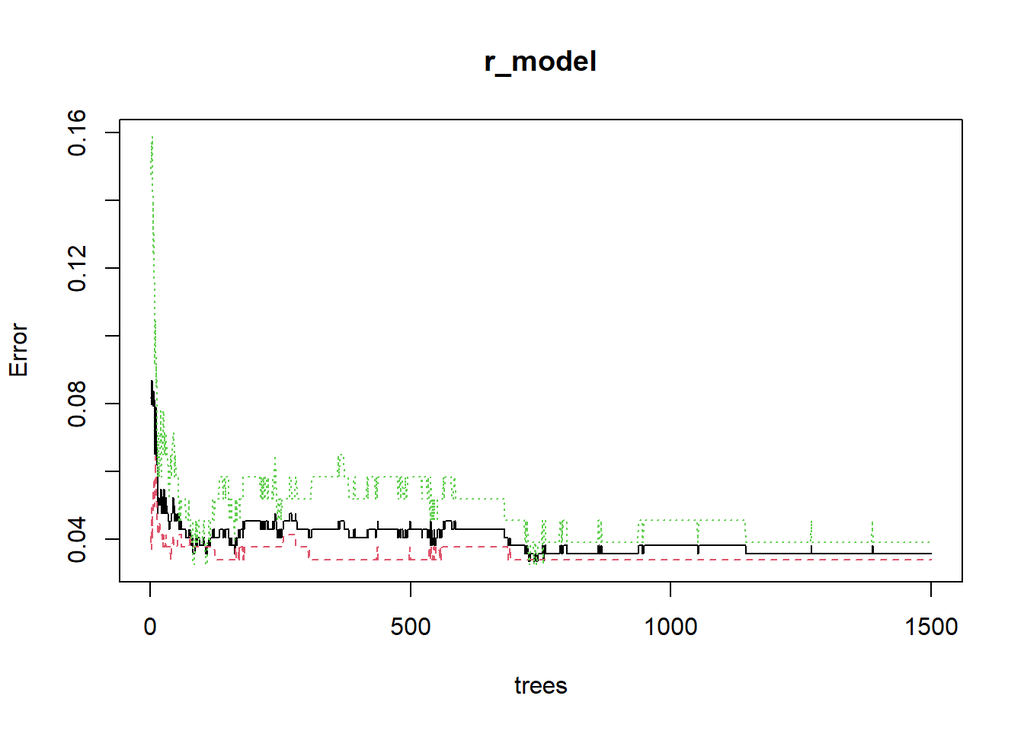

```r
plot(r_model)
```

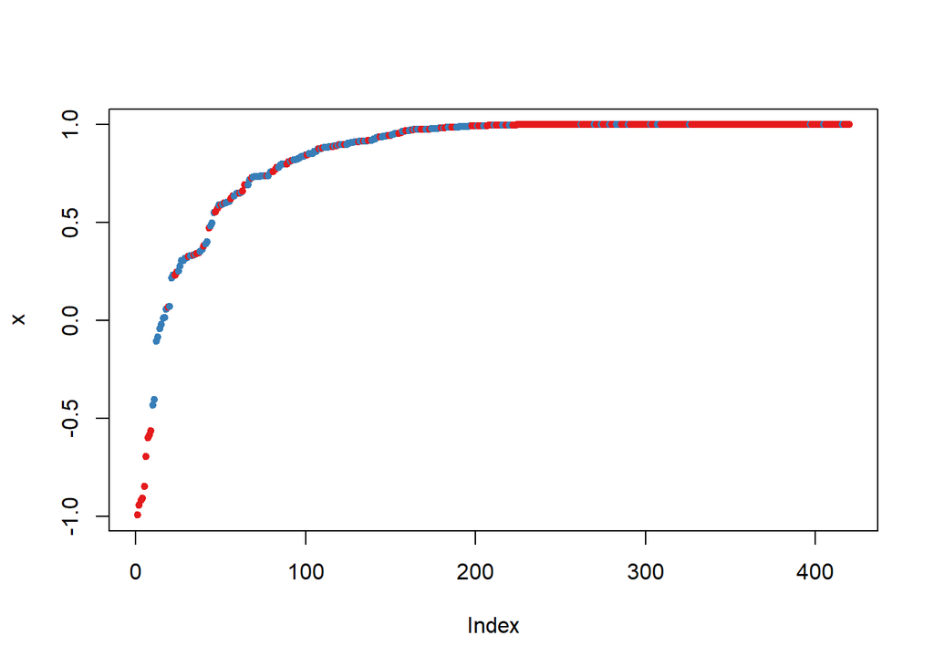

```r
plot(randomForest::margin(r_model,test_data$Outcome))
```

```r
# Predicting the model using test data

ran_pred <- predict(r_model,test_data)


#Display the confusion matrix or classification table

table(test_data$Outcome ,ran_pred)
```

```
##      ran_pred
##        No Yes
##   No  111   3
##   Yes   2  64
```

```r
# Predicting the probability matrix  using test data

ran_prob <- predict(r_model,test_data,type = "prob" )

ran_prob
```

```
##               No          Yes
## 2   0.1220000000 0.8780000000
## 5   1.0000000000 0.0000000000
## 7   0.4846666667 0.5153333333
## 9   0.9093333333 0.0906666667
## 17  1.0000000000 0.0000000000
## 23  1.0000000000 0.0000000000
## 25  1.0000000000 0.0000000000
## 26  0.2680000000 0.7320000000
## 32  1.0000000000 0.0000000000
## 33  0.0406666667 0.9593333333
## 37  0.0346666667 0.9653333333
## 39  0.0146666667 0.9853333333
## 46  1.0000000000 0.0000000000
## 47  0.0460000000 0.9540000000
```

[output cut: 168 more lines]

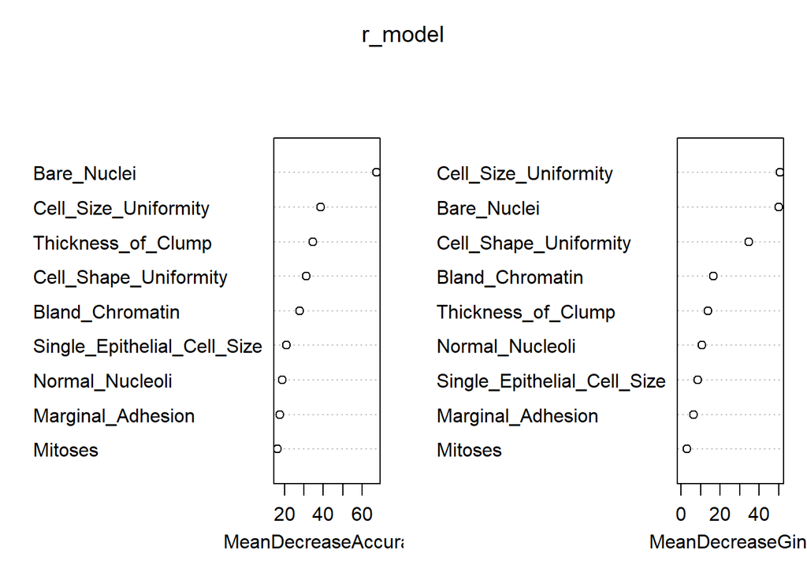

```r
varImpPlot(r_model)
```

```r
ran_prob1<-data.frame(ran_prob)
confusionMatrix(ran_pred, test_data$Outcome)
```

```
## Confusion Matrix and Statistics
##
##           Reference
## Prediction  No Yes
##        No  111   2
##        Yes   3  64
##
##                Accuracy : 0.9722
##                  95% CI : (0.9364, 0.9909)
##     No Information Rate : 0.6333
##     P-Value [Acc > NIR] : <2e-16
##
##                   Kappa : 0.9404
##
##  Mcnemar's Test P-Value : 1
##
##             Sensitivity : 0.9737
##             Specificity : 0.9697
##          Pos Pred Value : 0.9823
##          Neg Pred Value : 0.9552
##              Prevalence : 0.6333
##          Detection Rate : 0.6167
##    Detection Prevalence : 0.6278
##       Balanced Accuracy : 0.9717
##
##        'Positive' Class : No
##
```

# Trên thuật toán Descision Tree

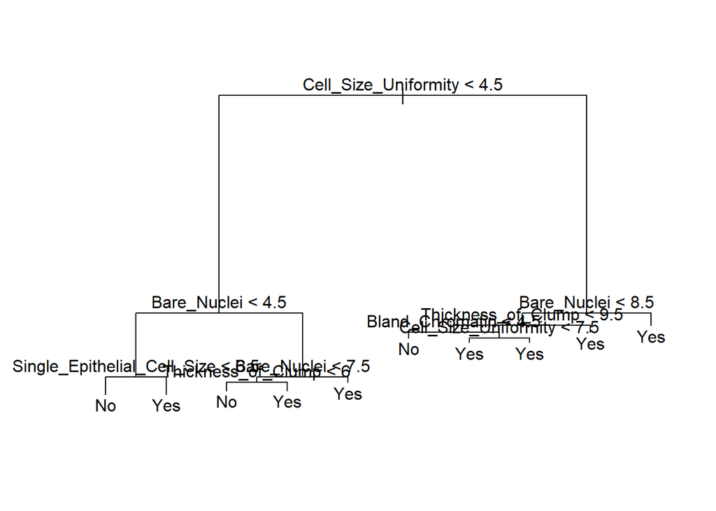

```r
#install.packages("tree")
library(class)
library(tree)
set.seed(1000)
training <- train_data
testing <- test_data
tree(Outcome~., data=training) ->treeRaw
# Create new plot window
plot(treeRaw)
text(treeRaw)
```

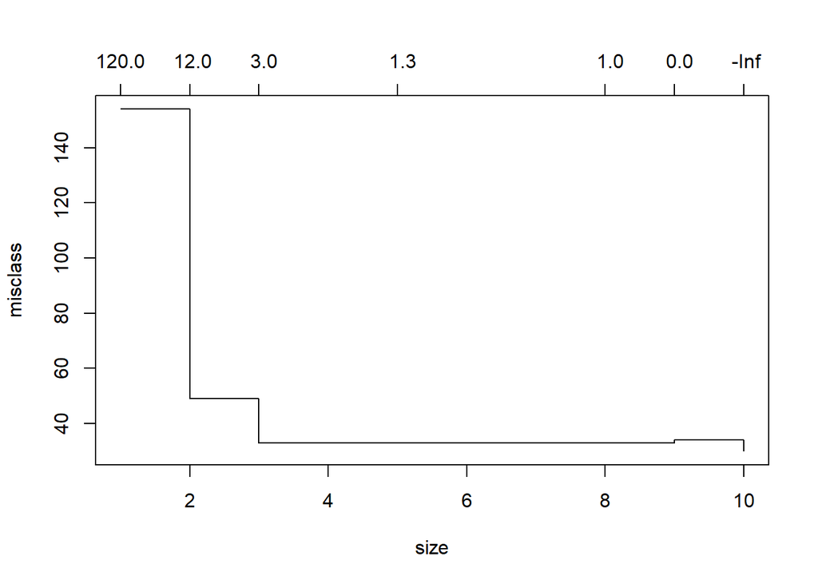

```r
cv_tree<-cv.tree(treeRaw, FUN=prune.misclass)

plot(cv_tree)
```

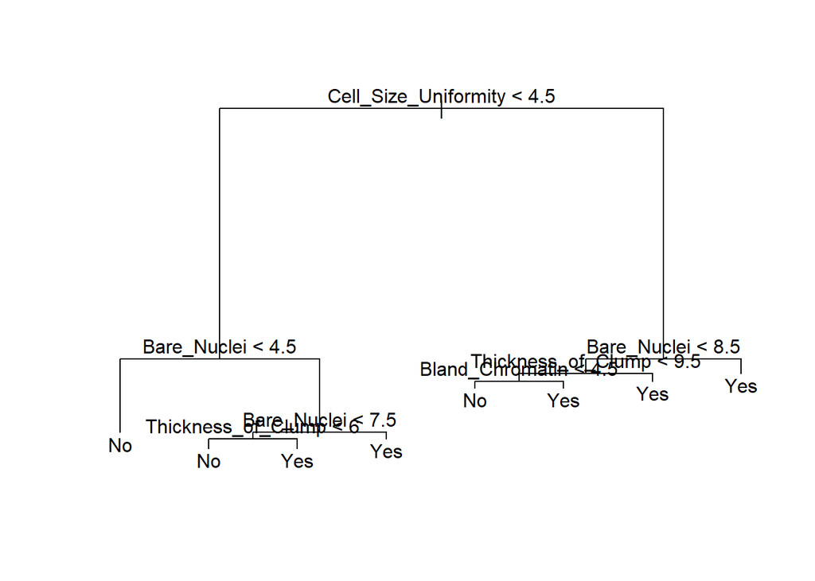

```r
prune.misclass(treeRaw, best=6) -> prune_tree
plot(prune_tree)
text(prune_tree, pretty=0)
```

```r
predict(prune_tree, testing, type='class') -> pred_test
confusionMatrix(pred_test, testing$Outcome)
```

```
## Confusion Matrix and Statistics
##
##           Reference
## Prediction  No Yes
##        No  111   4
##        Yes   3  62
##
##                Accuracy : 0.9611
##                  95% CI : (0.9215, 0.9842)
##     No Information Rate : 0.6333
##     P-Value [Acc > NIR] : <2e-16
##
##                   Kappa : 0.916
##
##  Mcnemar's Test P-Value : 1
##
##             Sensitivity : 0.9737
##             Specificity : 0.9394
##          Pos Pred Value : 0.9652
##          Neg Pred Value : 0.9538
##              Prevalence : 0.6333
##          Detection Rate : 0.6167
##    Detection Prevalence : 0.6389
##       Balanced Accuracy : 0.9565
##
##        'Positive' Class : No
##
```

# Trên thuật toán KNN (K Nearest Neighbors)

```r
#install.packages("gmodels")
library(class)
library(caTools)
library(caret)
library(gmodels)
set.seed(1000)


traindata_KNN <- train_data
testdata_KNN <- test_data


ctrl <-trainControl(method ="repeatedcv",
                    number =10,
                    repeats=5)


customGrid <-expand.grid(k=1:60)

train(Outcome~.,
      data=traindata_KNN,
      method = "knn",
      trControl = ctrl,
      preProcess= c("center","scale"),
      tuneGrid = customGrid,
      metric="Accuracy") -> knnFit

knnFit
```

```
## k-Nearest Neighbors
##
## 420 samples
##   9 predictor
##   2 classes: 'No', 'Yes'
##
## Pre-processing: centered (9), scaled (9)
## Resampling: Cross-Validated (10 fold, repeated 5 times)
## Summary of sample sizes: 378, 378, 378, 379, 379, 378, ...
## Resampling results across tuning parameters:
##
##   k   Accuracy   Kappa
##    1  0.9462202  0.8853214
##    2  0.9418875  0.8745061
##    3  0.9561681  0.9067464
```

[output cut: 60 more lines]

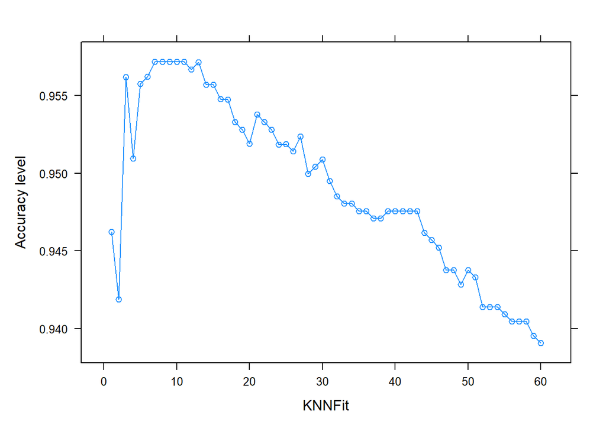

```r
plot(knnFit, type="b",col = "dodgerblue", xlab="KNNFit",ylab="Accuracy level")
```

```r
pred_test <-predict(knnFit, newdata = testdata_KNN)

confusionMatrix(pred_test, testdata_KNN$Outcome)
```

```
## Confusion Matrix and Statistics
##
##           Reference
## Prediction  No Yes
##        No  111   2
##        Yes   3  64
##
##                Accuracy : 0.9722
##                  95% CI : (0.9364, 0.9909)
##     No Information Rate : 0.6333
##     P-Value [Acc > NIR] : <2e-16
##
##                   Kappa : 0.9404
##
##  Mcnemar's Test P-Value : 1
##
##             Sensitivity : 0.9737
##             Specificity : 0.9697
##          Pos Pred Value : 0.9823
##          Neg Pred Value : 0.9552
##              Prevalence : 0.6333
##          Detection Rate : 0.6167
##    Detection Prevalence : 0.6278
##       Balanced Accuracy : 0.9717
##
##        'Positive' Class : No
##
```

# Thuật toán Navie Bayes

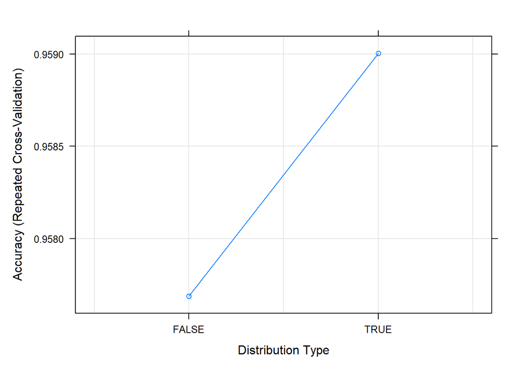

```r
#install.packages("e1071")
#install.packages("caret")
library(class)
library(caTools)
library(e1071)
library(caret)
set.seed(1000)

training <- train_data
testing <- test_data


ctrl <- trainControl(method="repeatedcv",repeats = 5)
navieBFit <- train(Outcome ~ .,
                 data = training,
                 method = "naive_bayes",
                trControl = ctrl,
                 preProcess = c("center","scale"),
                metric="Accuracy")

plot(navieBFit)
```

```r
predict(navieBFit, newdata = testing) -> pred_test
Outcome <- as.factor(testing$Outcome)
confusionMatrix(pred_test,Outcome )
```

```
## Confusion Matrix and Statistics
##
##           Reference
## Prediction  No Yes
##        No  111   1
##        Yes   3  65
##
##                Accuracy : 0.9778
##                  95% CI : (0.9441, 0.9939)
##     No Information Rate : 0.6333
##     P-Value [Acc > NIR] : <2e-16
##
##                   Kappa : 0.9525
##
##  Mcnemar's Test P-Value : 0.6171
##
##             Sensitivity : 0.9737
##             Specificity : 0.9848
##          Pos Pred Value : 0.9911
##          Neg Pred Value : 0.9559
##              Prevalence : 0.6333
##          Detection Rate : 0.6167
##    Detection Prevalence : 0.6222
##       Balanced Accuracy : 0.9793
##
##        'Positive' Class : No
##
```